# 決策樹

wuyijin

2019年2月1日

# 決策樹

- 不只要判斷清楚，也需要清楚的決策過程

  |  | 判斷清楚 | 決策過程 |
  | --- | --- | --- |
  | 目的 | 衡量新納入的變數能不能幫助我們判斷得更清楚， 包含分類問題、預測問題等 | 表達不同特徵 對於判斷目標的貢獻度與關係 |
  | 方法 | 在引入不同特徵後，計算不確定性， 用來衡量是否能判斷得更清楚 | 進一步將不確定性的過程視覺化 |
  | 解決方案 | 考量原始資料的各個特徵，並計算目前的不確定性 計算加入不同的變數後，是否能降低判斷的不確定性 找出判斷正確可能性最大的幾種決策路徑 |  |

- 吉尼不純度(Gini Imputity)

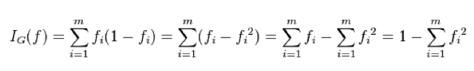

  - 衡量納入新特徵後，能否降低不確定程度
  - 衡量一個特徵能不能夠提升判斷得更清楚
  - 步驟
    - Step1：選取一個或多個特徵，並計算吉尼不純度
    - Step2：和選取前一次的結果做比較
    - Step3：重複前兩個步驟，直到吉尼不純度不能下降為止
- 熵

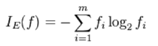

  - 衡量現有資訊的複雜(混亂)程度
  - 步驟
    - Step1：選取一個或多個特徵，並計算熵
    - Step2：和選取前一次的結果做比較
    - Step3：重複前兩個步驟，直到熵下降為止
- 吉尼不純度與熵比較

  |  | 吉尼不純度 | 熵 |
  | --- | --- | --- |
  | 原理 | 以判斷結果是否區分清楚， 降低不純度， 來衡量特徵對於判斷目標的幫助 | 以資訊的複雜度出發， 探討新的特徵能否降低整體複雜度， 進而更容易判斷 |
  | 強調 | 強調直觀理解判斷結果的 | 強調每次結果的資訊複雜度 資訊增益(Information Gain)度 計算這兩個指標的過程中， 下降多少不確定性， 增加了多少有用的資訊 |
  | 計算方式 |  |  |

- CART

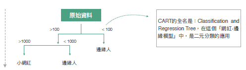

  - 由上而下建構的二分岔樹，讓不確定性或誤差平方最小
  - 流程
    - Step1：比較不同特徵的分類效果，以指標最小的特徵做為起點進行分岔
    - Step2：針對分岔後的各節點，繼續納入新的特徵進行分岔
    - Step3：若新的特徵無法使判斷指標繼續下降，則停止於該節點分岔
    - Step4：衡量整個模型的不確定性或誤差平方，直到無法再降低為止
    - Step5：保留現有結構，做為決策樹模型
  - rpart套件
    - R分類樹模型

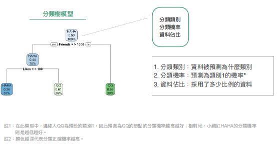

    - R迴歸數模型

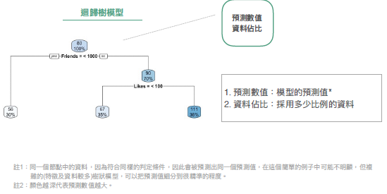

- 過度擬合與剪枝
  - 過度擬合(Over-fitting)
    - 決策樹模型為了配合目前觀察到的資料型態，而過度生長(過度複雜)；雖然能夠精準分類、預測現有資料，卻沒辦法提供正確的洞察，或應用在其他資料集上
  - 剪枝(Prune)
    - 修剪過度生長的分支
    - 方法
      - 交叉驗證：用訓練和驗證資料重複檢測
      - 統計檢測：檢驗是否在整體資料具有統計上的顯著差異
      - 衡量指標：如REP、PEP、CCP等指標，計算是否應該剪枝